# Summarise large scale characteristics

## 1.1 Introduction

In the previous vignette we have seen how we can use the CohortCharacteristics package to summarise a set of pre-specified characteristics of a study cohort. These characteristics included patient demographics like age and sex, and also concept sets and cohorts that we defined. Another, often complimentary, way that we can approach characterising a study cohort is by simply summarising all clinical events we see for them in some window around their index date (cohort entry).

To show how large scale characterisation can work we’ll first create a first-ever ankle sprain study cohort using the Eunomia synthetic data.

```r
library(omock)
library(CDMConnector)
library(dplyr, warn.conflicts = FALSE)
library(PatientProfiles)
library(CohortCharacteristics)

cdm <- mockCdmFromDataset(datasetName = "GiBleed", source = "duckdb")

cdm <- generateConceptCohortSet(
  cdm = cdm,
  name = "ankle_sprain",
  conceptSet = list("ankle_sprain" = 81151),
  end = "event_end_date",
  limit = "first",
  overwrite = TRUE
)
```

## 1.2 Large scale characteristics of study cohorts

To summarise our cohort of individuals with an ankle sprain we will look at their records in three tables of the OMOP CDM (*condition_occurrence*, *procedure_occurrence*, and *drug_exposure*) over two time windows (any time prior to their index date, and on index date). For conditions and procedures we will identify whether someone had a new record starting in the time window. Meanwhile, for drug exposures we will consider whether they had a new or ongoing record in the period.

```r
lsc <- cdm$ankle_sprain |>
  summariseLargeScaleCharacteristics(
    window = list(c(-Inf, -1), c(0, 0)),
    eventInWindow = c(
      "condition_occurrence",
      "procedure_occurrence"
    ),
    episodeInWindow = "drug_exposure",
    minimumFrequency = 0.1
  )

tableLargeScaleCharacteristics(lsc)
```

| cdm_name | cohort_name | window | concept_name | concept_id | percentage |
| --- | --- | --- | --- | --- | --- |
| GiBleed | ankle_sprain | -inf to -1 | Acute allergic reaction | 4084167 | 3.68 |
| GiBleed | ankle_sprain | -inf to -1 | Acute bacterial sinusitis | 4294548 | 12.38 |
| GiBleed | ankle_sprain | -inf to -1 | Acute bronchitis | 260139 | 56.52 |
| GiBleed | ankle_sprain | -inf to -1 | Acute viral pharyngitis | 4112343 | 62.27 |
| GiBleed | ankle_sprain | -inf to -1 | Angiodysplasia of stomach | 4310024 | 3.98 |
| GiBleed | ankle_sprain | -inf to -1 | Appendicitis | 440448 | 2.51 |
| GiBleed | ankle_sprain | -inf to -1 | Atopic dermatitis | 133834 | 2.14 |
| GiBleed | ankle_sprain | -inf to -1 | Child attention deficit disorder | 440086 | 5.53 |
| GiBleed | ankle_sprain | -inf to -1 | Childhood asthma | 4051466 | 2.65 |
| GiBleed | ankle_sprain | -inf to -1 | Chronic sinusitis | 257012 | 11.94 |

[output cut: 93 more lines]

As we can see we have identified numerous concepts for which at least 10% of our study population had a record. Often with larger cohorts and real patient-level data we will obtain many times more results when running large scale characterisation. One option we have to help summarise our results is to pick out the most frequent concepts. Here, for example, we select the top 5 concepts.

```r
tableTopLargeScaleCharacteristics(lsc,
                                  topConcepts = 5)
```

| Top | Window -inf to -1 Table name condition_occurrence Type event | Window -inf to -1 Table name drug_exposure Type episode | Window -inf to -1 Table name procedure_occurrence Type event | Window 0 to 0 Table name condition_occurrence Type event | Window 0 to 0 Table name drug_exposure Type episode |
| --- | --- | --- | --- | --- | --- |
| 1 | Viral sinusitis (40481087) 981 (72.3%) | poliovirus vaccine, inactivated (40213160) 994 (73.2%) | Suture open wound (4125906) 363 (26.8%) | Sprain of ankle (81151) 1357 (100.0%) | Aspirin 81 MG Oral Tablet (19059056) 470 (34.6%) |
| 2 | Otitis media (372328) 909 (67.0%) | Aspirin 81 MG Oral Tablet (19059056) 842 (62.0%) | Bone immobilization (4170947) 356 (26.2%) | – | Acetaminophen 325 MG Oral Tablet (1127433) 330 (24.3%) |
| 3 | Acute viral pharyngitis (4112343) 845 (62.3%) | Acetaminophen 325 MG Oral Tablet (1127433) 737 (54.3%) | Sputum examination (4151422) 282 (20.8%) | – | Acetaminophen 160 MG Oral Tablet (1127078) 199 (14.7%) |
| 4 | Acute bronchitis (260139) 767 (56.5%) | Acetaminophen 160 MG Oral Tablet (1127078) 559 (41.2%) | Plain chest X-ray (4163872) 137 (10.1%) | – | Ibuprofen 200 MG Oral Tablet (19078461) 192 (14.2%) |
| 5 | Streptococcal sore throat (28060) 499 (36.8%) | Amoxicillin 250 MG / Clavulanate 125 MG Oral Tablet (1713671) 499 (36.8%) | Radiography of humerus (4047491) 129 (9.5%) | – | Naproxen sodium 220 MG Oral Tablet (1115171) 120 (8.8%) |

## 1.3 Stratified large scale characteristics

Like when summarising pre-specified patient characteristics, we can also get stratified results when summarising large scale characteristics. Here, for example, large scale characteristics are stratified by sex (which we add as an additional column to our cohort table using the PatientProfiles package).

```r
lsc <- cdm$ankle_sprain |>
  addSex() |>
  summariseLargeScaleCharacteristics(
    window = list(c(-Inf, -1), c(0, 0)),
    strata = list("sex"),
    eventInWindow = "drug_exposure",
    minimumFrequency = 0.1
  )

tableTopLargeScaleCharacteristics(lsc)
```

| Top | Sex Female Window -inf to -1 | Sex Female Window 0 to 0 | Sex Male Window -inf to -1 | Sex Male Window 0 to 0 | Sex overall Window -inf to -1 | Sex overall Window 0 to 0 |
| --- | --- | --- | --- | --- | --- | --- |
| 1 | poliovirus vaccine, inactivated (40213160) 501 (73.3%) | Aspirin 81 MG Oral Tablet (19059056) 245 (35.9%) | poliovirus vaccine, inactivated (40213160) 493 (73.2%) | Aspirin 81 MG Oral Tablet (19059056) 225 (33.4%) | poliovirus vaccine, inactivated (40213160) 994 (73.2%) | Aspirin 81 MG Oral Tablet (19059056) 470 (34.6%) |
| 2 | Aspirin 81 MG Oral Tablet (19059056) 427 (62.5%) | Acetaminophen 325 MG Oral Tablet (1127433) 165 (24.2%) | Aspirin 81 MG Oral Tablet (19059056) 415 (61.6%) | Acetaminophen 325 MG Oral Tablet (1127433) 165 (24.5%) | Aspirin 81 MG Oral Tablet (19059056) 842 (62.0%) | Acetaminophen 325 MG Oral Tablet (1127433) 330 (24.3%) |
| 3 | Acetaminophen 325 MG Oral Tablet (1127433) 374 (54.8%) | Acetaminophen 160 MG Oral Tablet (1127078) 97 (14.2%) | Acetaminophen 325 MG Oral Tablet (1127433) 363 (53.9%) | Acetaminophen 160 MG Oral Tablet (1127078) 102 (15.1%) | Acetaminophen 325 MG Oral Tablet (1127433) 737 (54.3%) | Acetaminophen 160 MG Oral Tablet (1127078) 199 (14.7%) |
| 4 | Acetaminophen 160 MG Oral Tablet (1127078) 292 (42.8%) | Ibuprofen 200 MG Oral Tablet (19078461) 93 (13.6%) | Acetaminophen 160 MG Oral Tablet (1127078) 267 (39.6%) | Ibuprofen 200 MG Oral Tablet (19078461) 99 (14.7%) | Acetaminophen 160 MG Oral Tablet (1127078) 559 (41.2%) | Ibuprofen 200 MG Oral Tablet (19078461) 192 (14.2%) |
| 5 | Penicillin V Potassium 250 MG Oral Tablet (19133873) 256 (37.5%) | Naproxen sodium 220 MG Oral Tablet (1115171) 62 (9.1%) | Amoxicillin 250 MG / Clavulanate 125 MG Oral Tablet (1713671) 255 (37.8%) | Naproxen sodium 220 MG Oral Tablet (1115171) 58 (8.6%) | Amoxicillin 250 MG / Clavulanate 125 MG Oral Tablet (1713671) 499 (36.8%) | Naproxen sodium 220 MG Oral Tablet (1115171) 120 (8.8%) |
| 6 | Amoxicillin 250 MG / Clavulanate 125 MG Oral Tablet (1713671) 244 (35.7%) | Ibuprofen 100 MG Oral Tablet (19019979) 21 (3.1%) | Penicillin V Potassium 250 MG Oral Tablet (19133873) 235 (34.9%) | Ibuprofen 100 MG Oral Tablet (19019979) 25 (3.7%) | Penicillin V Potassium 250 MG Oral Tablet (19133873) 491 (36.2%) | Ibuprofen 100 MG Oral Tablet (19019979) 46 (3.4%) |
| 7 | Penicillin G 375 MG/ML Injectable Solution (19006318) 169 (24.7%) | – | Penicillin G 375 MG/ML Injectable Solution (19006318) 215 (31.9%) | – | Penicillin G 375 MG/ML Injectable Solution (19006318) 384 (28.3%) | – |
| 8 | tetanus and diphtheria toxoids, adsorbed, preservative free, for adult use (40213227) 151 (22.1%) | – | Acetaminophen 21.7 MG/ML / Dextromethorphan Hydrobromide 1 MG/ML / doxylamine succinate 0.417 MG/ML Oral Solution (40229134) 164 (24.3%) | – | Acetaminophen 21.7 MG/ML / Dextromethorphan Hydrobromide 1 MG/ML / doxylamine succinate 0.417 MG/ML Oral Solution (40229134) 296 (21.8%) | – |
| 9 | {7 (Inert Ingredients 1 MG Oral Tablet) / 21 (Mestranol 0.05 MG / Norethindrone 1 MG Oral Tablet) } Pack [Norinyl 1+50 28 Day] (19128065) 135 (19.8%) | – | tetanus and diphtheria toxoids, adsorbed, preservative free, for adult use (40213227) 137 (20.3%) | – | tetanus and diphtheria toxoids, adsorbed, preservative free, for adult use (40213227) 288 (21.2%) | – |
| 10 | Acetaminophen 21.7 MG/ML / Dextromethorphan Hydrobromide 1 MG/ML / doxylamine succinate 0.417 MG/ML Oral Solution (40229134) 132 (19.3%) | – | Haemophilus influenzae type b vaccine, PRP-OMP conjugate (40213314) 98 (14.5%) | – | hepatitis B vaccine, adult dosage (40213306) 226 (16.6%) | – |

## 1.4 Plot large scale characteristics

`plotLargeScaleCharacteristics` and `plotComparedLargeScaleCharacteristics` can be use to generate plot for visualising the large scale characteristics

```r
plotLargeScaleCharacteristics(lsc)
```

[output not shown]

`plotComparedLargeScaleCharacteristics` allows you to compare the difference in prevalence of the large scale covariates between two window. The reference cohort and time window are set using the `reference` arguement inside the function.

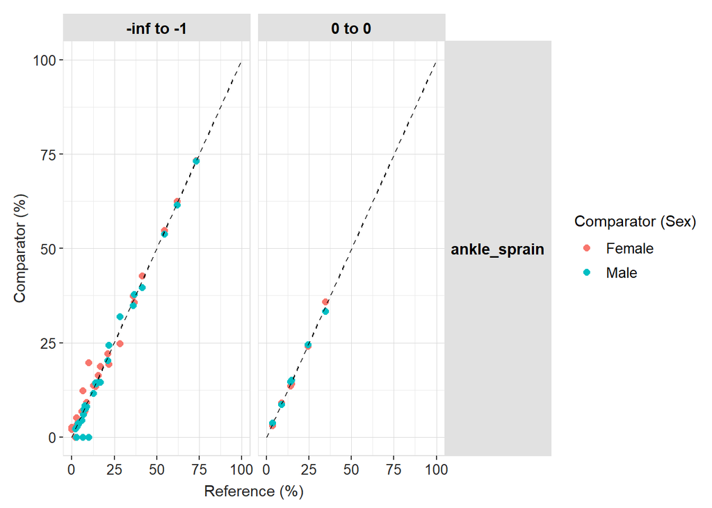

```r
plotComparedLargeScaleCharacteristics(
  result = lsc,
  colour = "sex",
  reference = 'overall',
  facet = cohort_name ~ variable_level
)
```